# 個人プロジェクト

阿部 菜月

2021/12/17

```r
library(NipponMap)
library(RColorBrewer)
library(ggplot2)
library(sf)
library(tidyverse)
library(readxl)

#ディレクトリの変更
setwd("C:/Rdata")
```

## 1. はじめに

1. なぜこのテーマを取り上げたのか?
- 自らの大学受験の経験から、このテーマを身近に感じ、大学の進学率は何に依存するのかについて興味を持ったため。

## 2. 仮説

「家計に占める教育費が高いほど進学率も高くなる。」

## 3. 問題の背景

```r
singakudata<-readxl::read_excel("singaku.xlsx",skip=16,sheet=1)
```

```
## * `` -> ...2
## * `` -> ...3
## * `` -> ...23
## * `` -> ...24
```

```r
educationdata<-readxl::read_excel("education.xls",skip=12,sheet=1)
```

```
## * `` -> ...1
## * `` -> ...2
## * `` -> ...3
## * `` -> ...4
## * `` -> ...5
## * ...
```

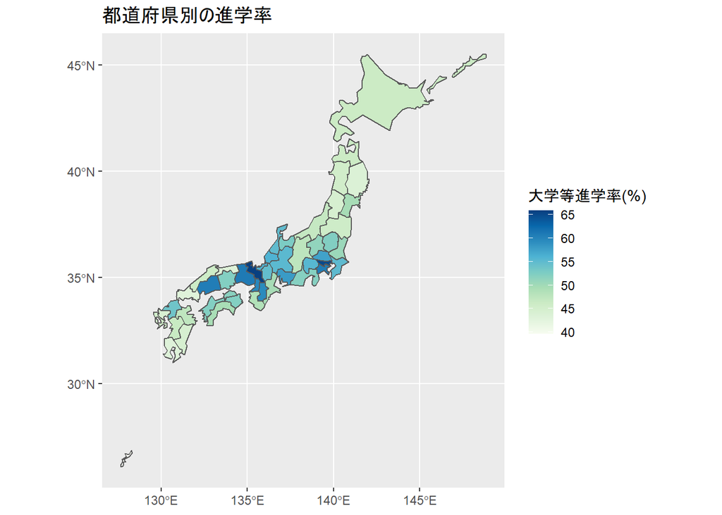

```r
projectdata<-left_join(singakudata,educationdata,by="code")
projectdata2<- projectdata %>%
  select(code, prefj.x , kyouikuhi, singakuritu, incomeA)

map <- read_sf(system.file("shapes/jpn.shp", package = "NipponMap")[1],
               crs = "+proj=longlat +datum=WGS84")

mapDB<-left_join(map,projectdata2, by=c("jiscode"="code"))

ggplot(mapDB, aes(fill = singakuritu)) +
  geom_sf() +
  scale_fill_gradientn(colors=brewer.pal(9,"GnBu"))+
  labs(fill = "大学等進学率(%)")+
  ggtitle("都道府県別の進学率")
```

- データ出所
- 学校基本調査 (2019)

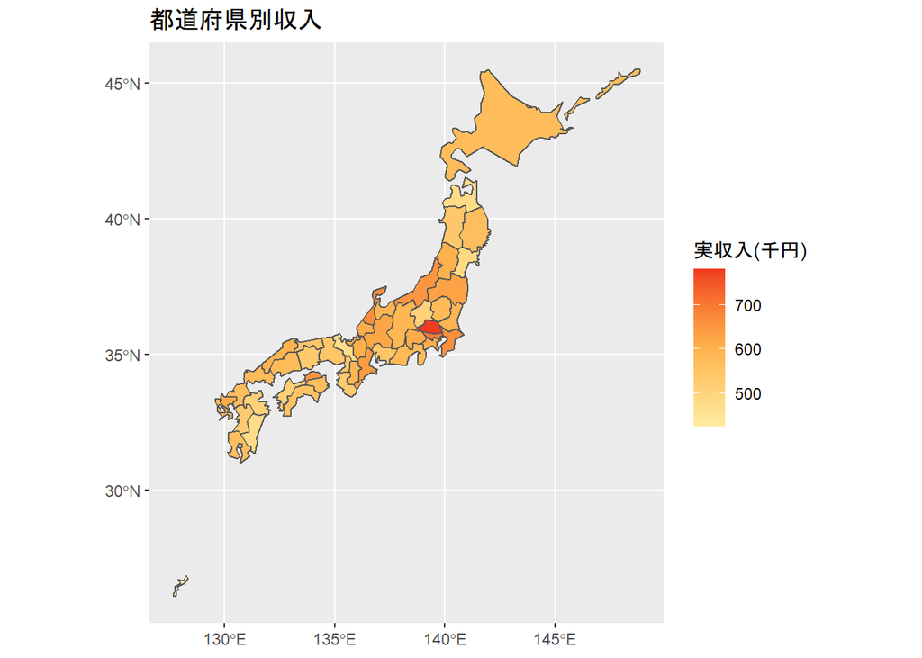

```r
mapDB$incomeA<-as.numeric(mapDB$incomeA)

ggplot(mapDB, aes(fill = incomeA)) +
  geom_sf() +
  scale_fill_gradientn(colors=brewer.pal(3,"YlOrRd"))+
  labs(fill = "実収入(千円)")+
  ggtitle("都道府県別収入")
```

- データ出所
- 家計(2019)

## 4. 分析

### 4.1 データの紹介

使用するデータの紹介 -e-Stat

- 学校基本調査 (2019) https://www.e-stat.go.jp/stat-search/files?page=1&toukei=00400001&tstat=000001011528
- 家計(2019) https://www.e-stat.go.jp/stat-search/files?page=1&layout=datalist&toukei=00200502&tstat=000001149949&cycle=0&year=20210&month=0&tclass1=000001149950&tclass2val=0
- 令和元年版高齢社会白書 https://www8.cao.go.jp/kourei/whitepaper/w-2020/zenbun/pdf/1s1s_04.pdf

### 4.2 分析方法

- 回帰分析(1)

```r
result<-lm(singakuritu~kyouikuhi,data=projectdata2)
summary(result)
```

```
##
## Call:
## lm(formula = singakuritu ~ kyouikuhi, data = projectdata2)
##
## Residuals:
##      Min       1Q   Median       3Q      Max
## -10.8969  -2.5646  -0.0585   2.8657  10.0320
##
## Coefficients:
##             Estimate Std. Error t value Pr(>|t|)
## (Intercept)  37.2094     2.5652  14.506  < 2e-16 ***
## kyouikuhi     3.7451     0.6599   5.676 9.44e-07 ***
## ---
## Signif. codes:  0 '***' 0.001 '**' 0.01 '*' 0.05 '.' 0.1 ' ' 1
##
## Residual standard error: 4.824 on 45 degrees of freedom
##   ( 8 個の観測値が欠損のため削除されました )
## Multiple R-squared:  0.4172, Adjusted R-squared:  0.4042
## F-statistic: 32.21 on 1 and 45 DF,  p-value: 9.438e-07
```

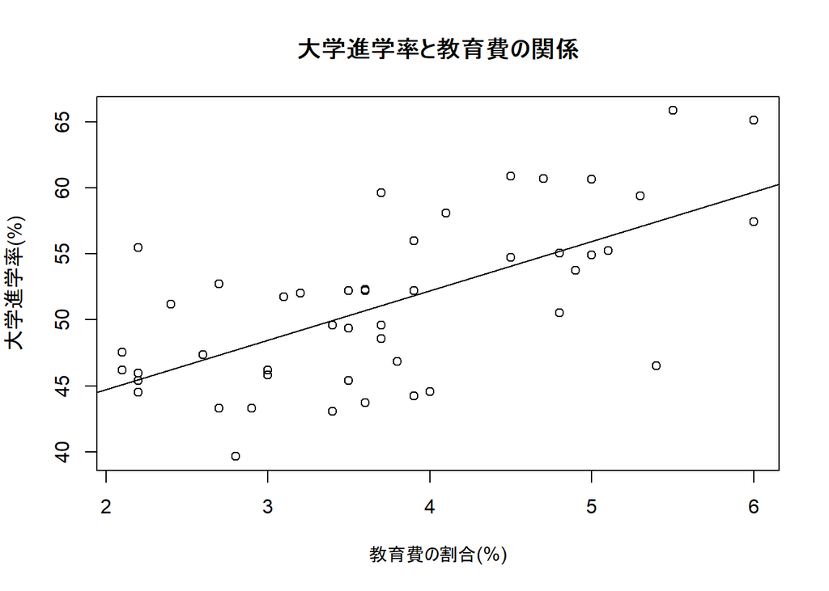

```r
plot(projectdata2$kyouikuhi,projectdata2$singakuritu,main="大学進学率と教育費の関係",xlab="教育費の割合(%)",ylab="大学進学率(%)")

abline(result)
```

- 回帰分析(2)

```r
projectdata2$incomeA<-as.numeric(projectdata2$incomeA)
result2<-lm(singakuritu~kyouikuhi+incomeA,data=projectdata2)
summary(result2)
```

```
##
## Call:
## lm(formula = singakuritu ~ kyouikuhi + incomeA, data = projectdata2)
##
## Residuals:
##      Min       1Q   Median       3Q      Max
## -10.6124  -2.7992  -0.1888   2.6842   9.7873
##
## Coefficients:
##              Estimate Std. Error t value Pr(>|t|)
## (Intercept) 35.615819   6.495162   5.483 1.93e-06 ***
## kyouikuhi    3.667357   0.727390   5.042 8.40e-06 ***
## incomeA      0.003267   0.012211   0.268     0.79
## ---
## Signif. codes:  0 '***' 0.001 '**' 0.01 '*' 0.05 '.' 0.1 ' ' 1
##
## Residual standard error: 4.875 on 44 degrees of freedom
##   ( 8 個の観測値が欠損のため削除されました )
## Multiple R-squared:  0.4181, Adjusted R-squared:  0.3917
## F-statistic: 15.81 on 2 and 44 DF,  p-value: 6.698e-06
```

- 回帰分析(3)

```r
koureika<-readxl::read_excel("koureika.xlsx",skip=1,sheet=1)
projectdata3<-left_join(projectdata2,koureika,by="code")
result3<-lm(singakuritu~koureika+incomeA+kyouikuhi,data=projectdata3)
summary(result3)
```

```
##
## Call:
## lm(formula = singakuritu ~ koureika + incomeA + kyouikuhi, data = projectdata3)
##
## Residuals:
##     Min      1Q  Median      3Q     Max
## -12.678  -2.625  -0.170   3.077   9.292
##
## Coefficients:
##              Estimate Std. Error t value Pr(>|t|)
## (Intercept) 54.385992  10.777420   5.046  8.7e-06 ***
## koureika    -0.549977   0.257328  -2.137 0.038305 *
## incomeA      0.004804   0.011766   0.408 0.685052
## kyouikuhi    2.896306   0.787123   3.680 0.000646 ***
## ---
## Signif. codes:  0 '***' 0.001 '**' 0.01 '*' 0.05 '.' 0.1 ' ' 1
##
## Residual standard error: 4.688 on 43 degrees of freedom
##   ( 8 個の観測値が欠損のため削除されました )
## Multiple R-squared:  0.474,  Adjusted R-squared:  0.4373
## F-statistic: 12.92 on 3 and 43 DF,  p-value: 3.76e-06
```

### 4.3 分析結果

- 回帰分析(1)より、教育費はp値が0.000000944で0.1よりもかなり低い値であるため、教育費が高くなると進学率も高くなると言える。また、回帰分析(2)から進学率は所得に依存しないことが分かる。回帰分析(3)は高齢化率が高いほど大学進学率は低いことを示す結果となった。

## 5. 考察

- 家計に占める教育費の割合の増加は大学進学率の増加の要因となる。この結果から所得が低い世帯でも教育費の割合を増加させることができれば、子供を進学させることができると言える。また、大学進学率が所得に依存しないのは、所得に学生がいない世帯も含まれているためであると考えることができる。高齢化率が高いと進学率が低いのは子供の母数が少ないことにより学校の数も減るからであると考察する。